# Verzani Problem Set

### Problem 4.6

For the data set `emissions` plot the per-Capita GDP (gross domestic product) as a predictor for the response variable $CO_2$ emissions. Identify the outlier and find the regression lines with this point, and without this point.

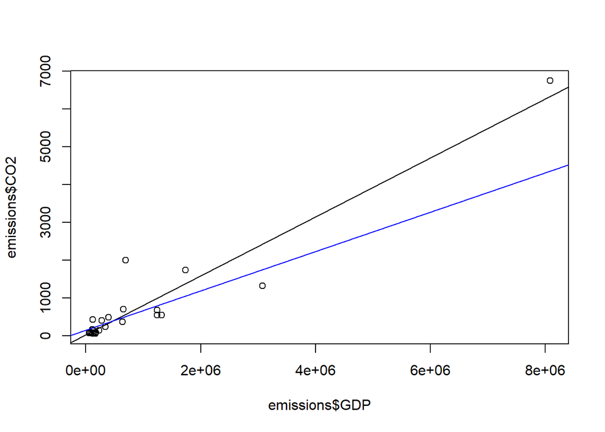

```r
> plot(emissions$CO2 ~ emissions$GDP)
> model <- lm(emissions$CO2 ~ emissions$GDP)
> abline(model)
> identify(emissions$GDP, emissions$CO2)
integer(0)
> model.clean <- lm(emissions[-1,]$CO2 ~ emissions[-1,]$GDP)
> abline(model.clean, col = "Blue")
```

### Problem 4.7

Attach the data set `babies`:

```r
> attach(babies)
```

This data set contains much information about babies and their mothers for 1236 observations. Find the correlation coefficient (both Pearson and Spearman) between age and weight.

```r
> cor(wt, age)
[1] 0.02904064
> cor(rank(wt), rank(age))
[1] 0.04170028
```

Repeat for the relationship between height and weight.

```r
> cor(wt, ht)
[1] 0.1255413
> cor(rank(wt), rank(ht))
[1] 0.214745
```

Make scatter plots of each pair and see if your answer makes sense.

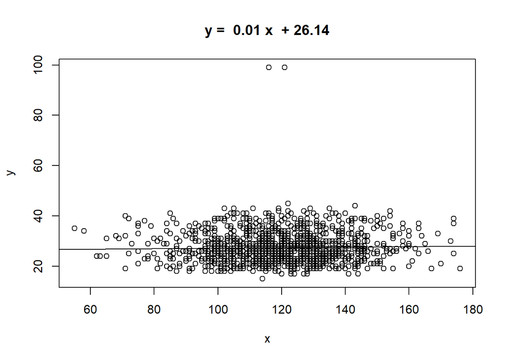

```
Call:
lm(formula = y ~ x)

Coefficients:
(Intercept)            x
   26.14182      0.01028
```

```r
> simple.lm(wt, age)
```

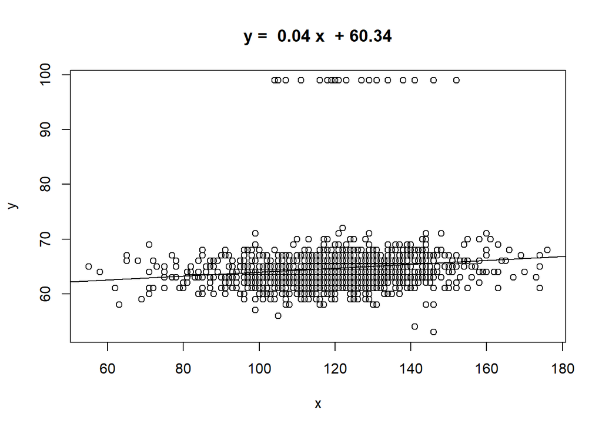

```
Call:
lm(formula = y ~ x)

Coefficients:
(Intercept)            x
   60.33911      0.03622
```

```r
> simple.lm(wt, ht)
```

### Problem 4.9

The built-in data set `mtcars` contains information about cars from a 1974 Motor Trend issue. Try to answer the following:

1. What are the variable names? (Try `names`.)

```r
> names(mtcars)
 [1] "mpg"  "cyl"  "disp" "hp"   "drat" "wt"   "qsec" "vs"   "am"   "gear"
[11] "carb"
```

2. What is the maximum `mpg`

```r
> max(mtcars$mpg)
[1] 33.9
```

3. Which car has this?

```r
> rownames(mtcars[which.max(mtcars$mpg), ])
[1] "Toyota Corolla"
```

4. What are the first 5 cars listed?

```r
> rownames(mtcars)[1:5]
[1] "Mazda RX4"         "Mazda RX4 Wag"     "Datsun 710"
[4] "Hornet 4 Drive"    "Hornet Sportabout"
```

5. What horsepower (`hp`) does the “Valiant” have?

```r
> mtcars["Valiant", "hp"]
[1] 105
```

6. What are all the values for the Mercedes 450slc (`Merc 450SLC`)?

```r
> mtcars["Merc 450SLC", ]
             mpg cyl  disp  hp drat   wt qsec vs am gear carb
Merc 450SLC 15.2   8 275.8 180 3.07 3.78   18  0  0    3    3
```

7. Make a scatterplot of cylinders (`cyl`) vs. miles per gallon (`mpg`). Fit a regression line. Is this a good candidate for linear regression?

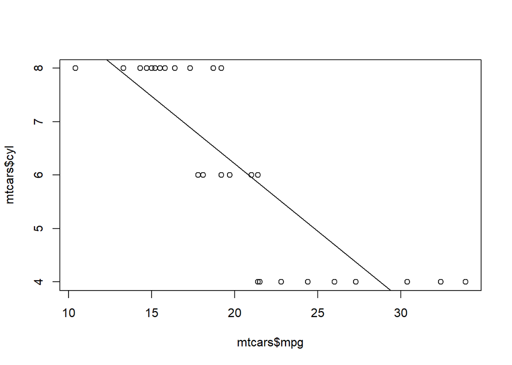

```r
> plot(mtcars$cyl ~ mtcars$mpg)
> abline(lm(mtcars$cyl ~ mtcars$mpg))
```

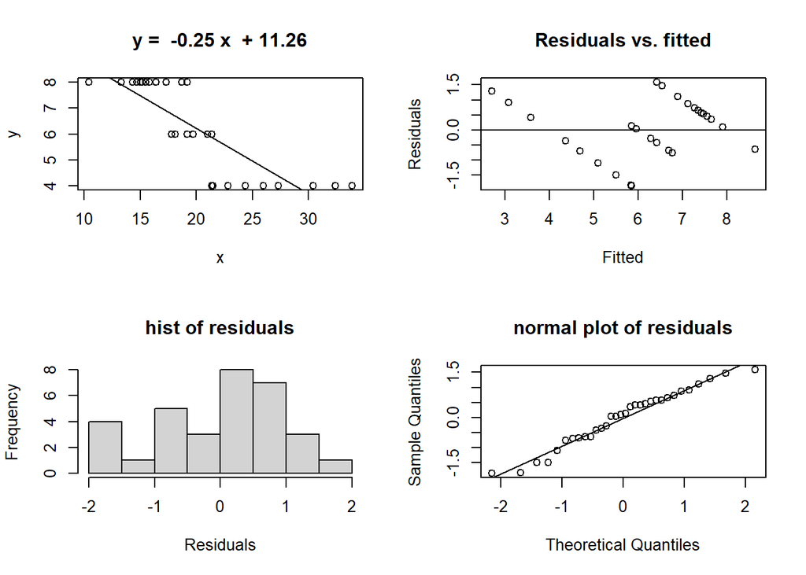

```
Call:
lm(formula = y ~ x)

Coefficients:
(Intercept)            x
    11.2607      -0.2525
```

```r
> simple.lm(mtcars$mpg, mtcars$cyl, show.residuals = TRUE)
```